# Memo - Exploring post-1935 exposure data

## Purpose

The goal of this notebook is to explore initial exposure data for HOLC neighborhoods across the U.S. for wells with production dates on or after 1/1/1935 (approximately the time of HOLC grading).

## Cities

#### Table. Number of wells within 1 km of graded neighborhoods

| city_state | buffer_1km_wells_all_n |
| --- | --- |
| Los Angeles - CA | 5565 |
| Oklahoma City - OK | 807 |
| Erie - PA | 701 |
| Akron - OH | 470 |
| Fort Worth - TX | 422 |
| Canton - OH | 379 |
| Tulsa - OK | 279 |
| Cleveland - OH | 267 |
| Youngstown - OH | 244 |
| San Antonio - TX | 192 |

[output cut: 17 more lines]

## Wells

A total of 745062 wells had a spud date, completion date, and/or production start or end date after 1935 (and excluded wells with production dates before 1935.)

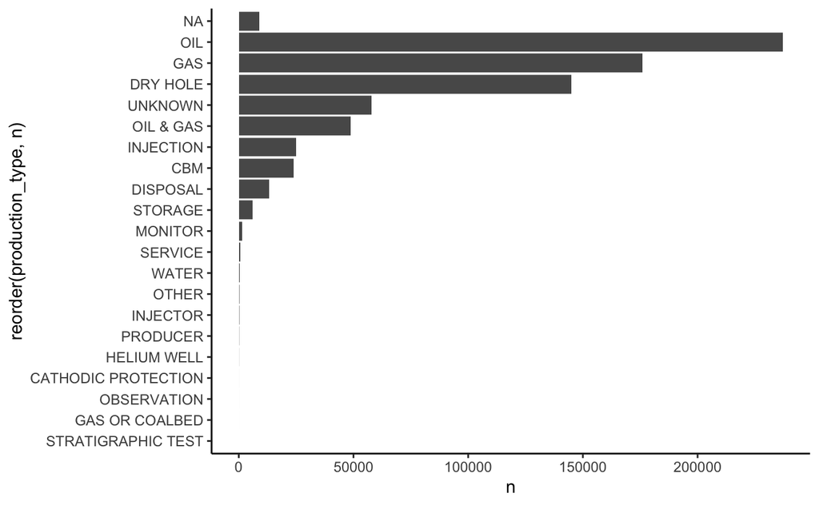

## Exposure to all wells

Unit of observation is the neighborhood

### All wells within 1 km of neighborhood centroid

#### Plot. Histogram of n all wells within 1 km

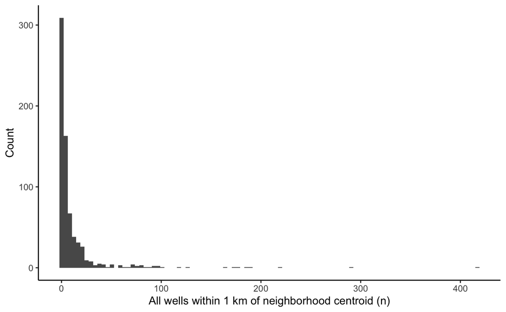

#### Plot. Histogram of n all wells within 1 km, all cities

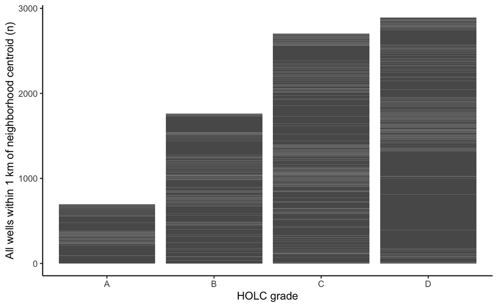

#### Plot. Histogram of n all wells within 1 km, by city

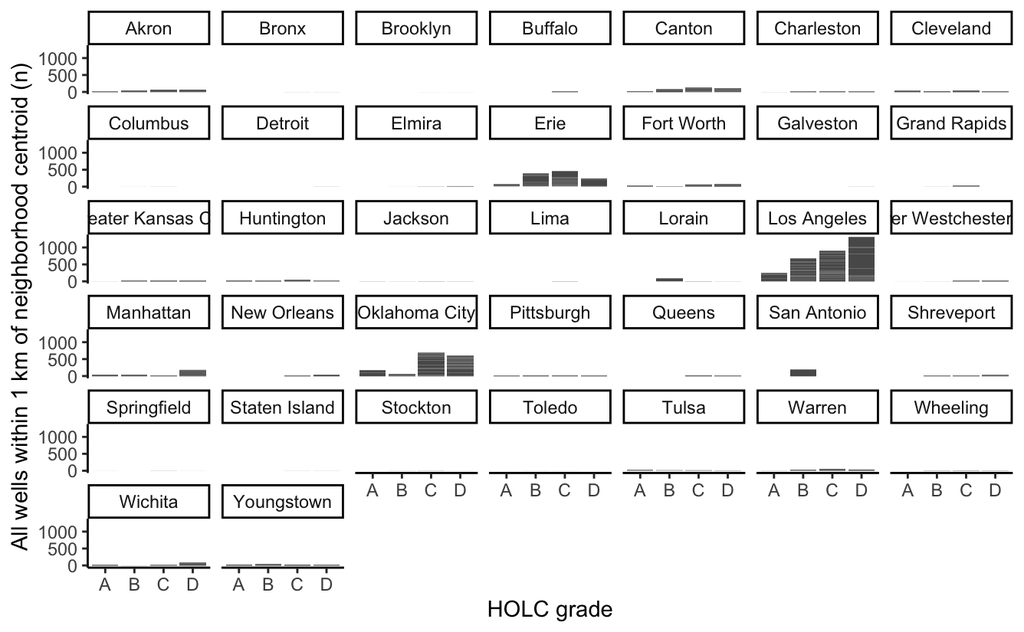

### All wells within 3 km of neighborhood centroid

#### Plot. Histogram of n all wells within 3 km

Restricted to neighborhood with > 0 wells

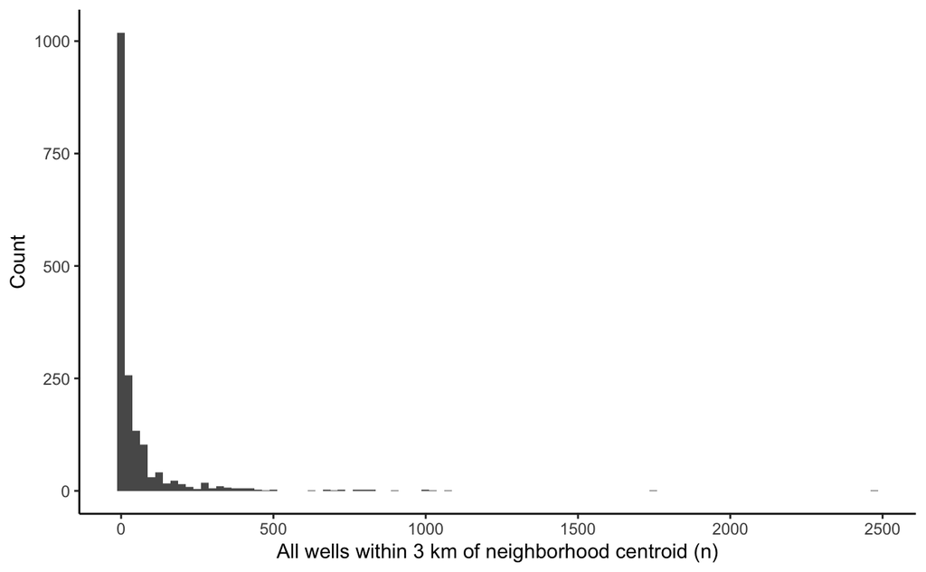

#### Plot. Histogram of n all wells within 3 km, all cities

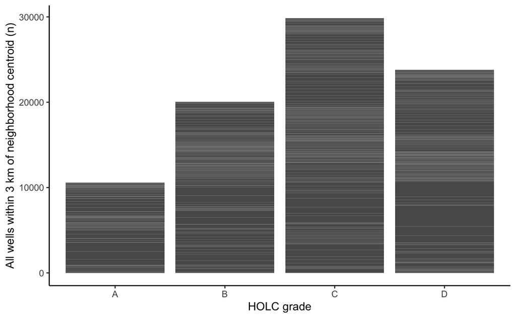

#### Plot. Histogram of n all wells within 3 km, by city

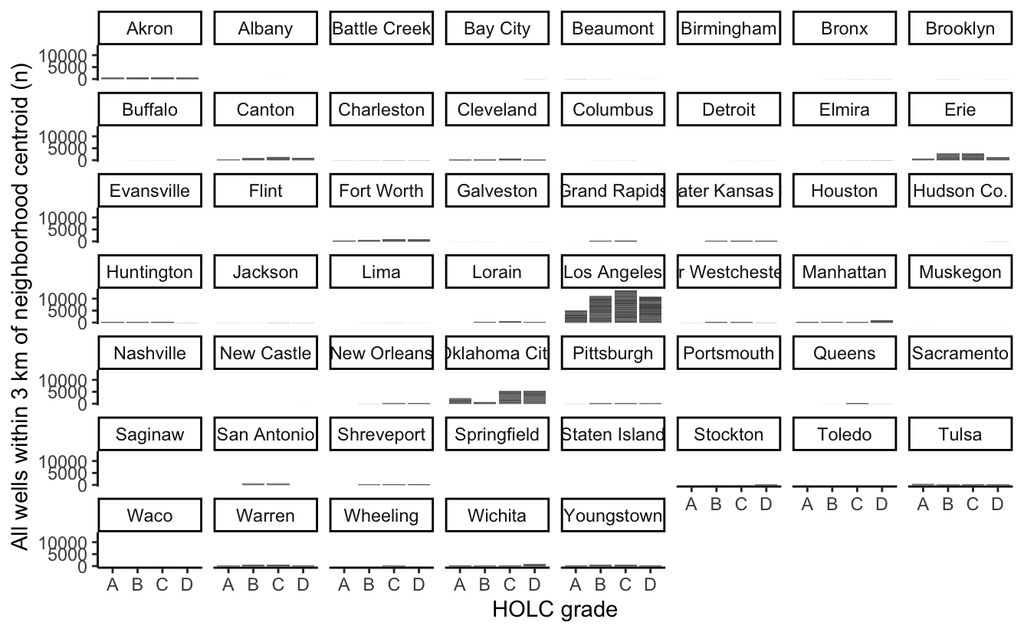

## Exposure to oil and gas wells

Unit of observation is the neighborhood

### Oil and gas wells within 1 km of neighborhood centroid

#### Plot. Histogram of n oil and gas wells within 1 km

Note: Right skew in the data; most neighborhoods were unexposed.

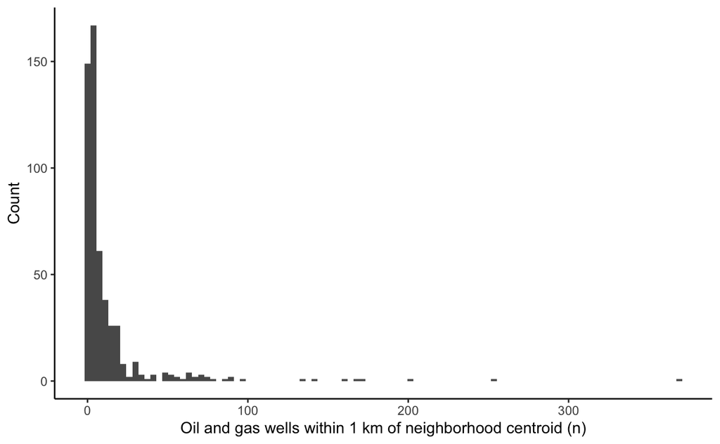

#### Plot. Histogram of n oil and gas wells within 1 km, all cities

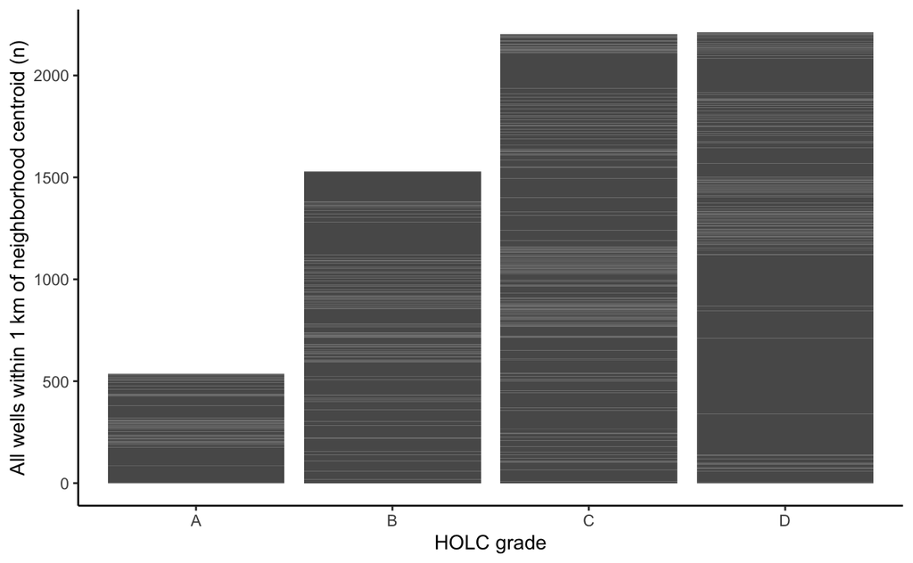

#### Plot. Histogram of n oil and gas wells within 1 km, by city

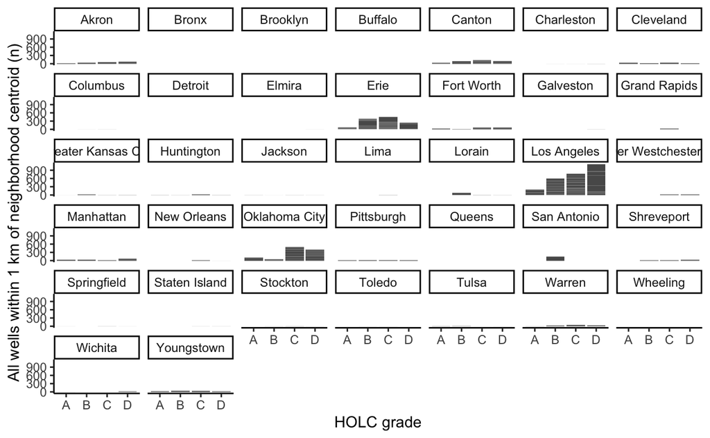

## Exposure to injection wells

Only 1 neighborhood had an injection well within 1 km and 29 had at least one well within 3 km. I’ll exclude injection wells for the pre-1935 analyses.

## Exposure to producing wells

Producing wells were defined as wells with > 0 BOE of oil and/or gas production, as reported in the Enverus dataset.

### Producing wells within 1 km of neighborhood centroid

#### Plot. Histogram of n producing wells within 1 km

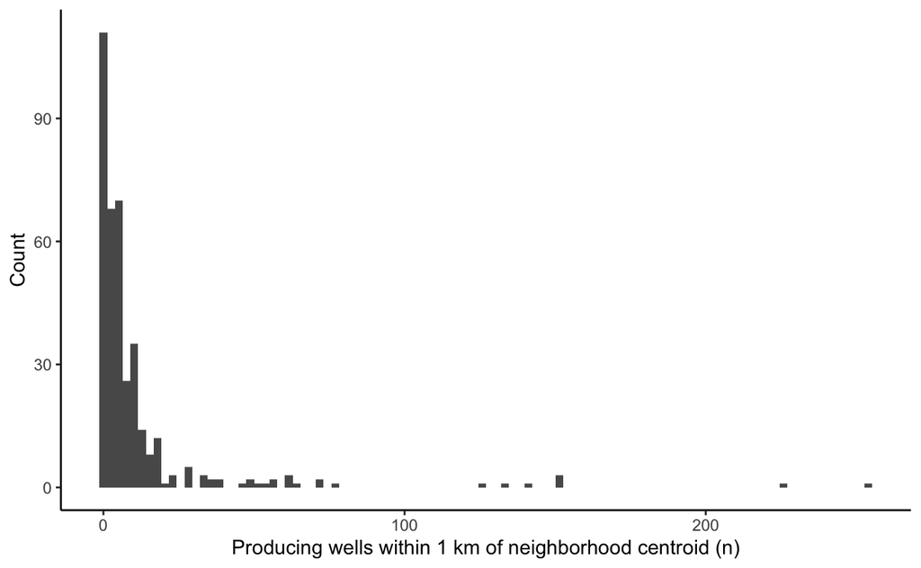

#### Plot. Histogram of n producing wells within 1 km, all cities

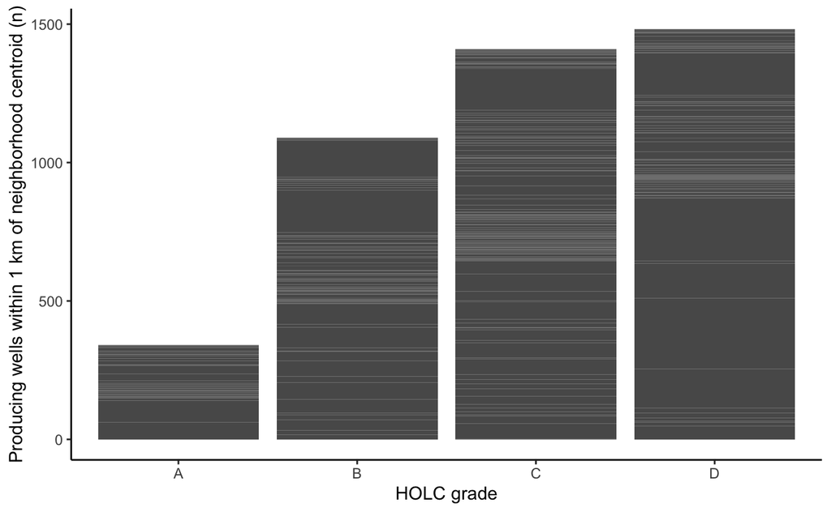

#### Plot. Histogram of n producing wells within 1 km, by city

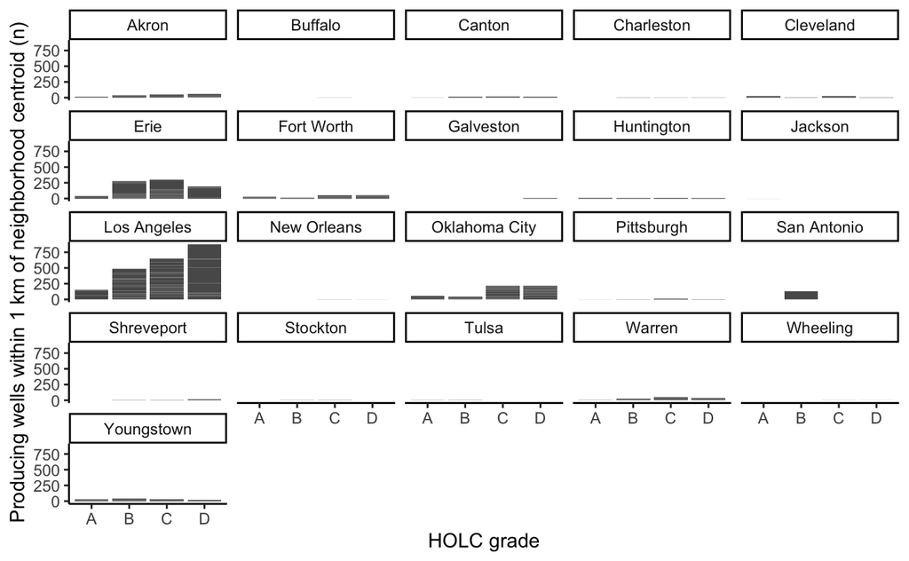

### Producing wells within 3 km of neighborhood centroid

#### Plot. Histogram of n producing wells within 3 km

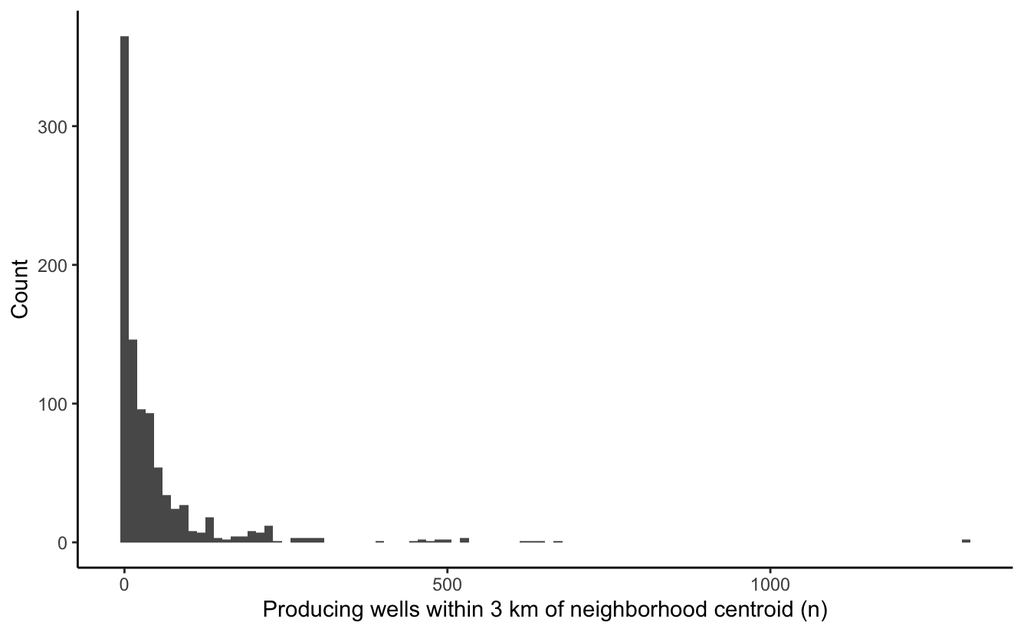

#### Plot. Histogram of n producing wells within 3 km, all cities

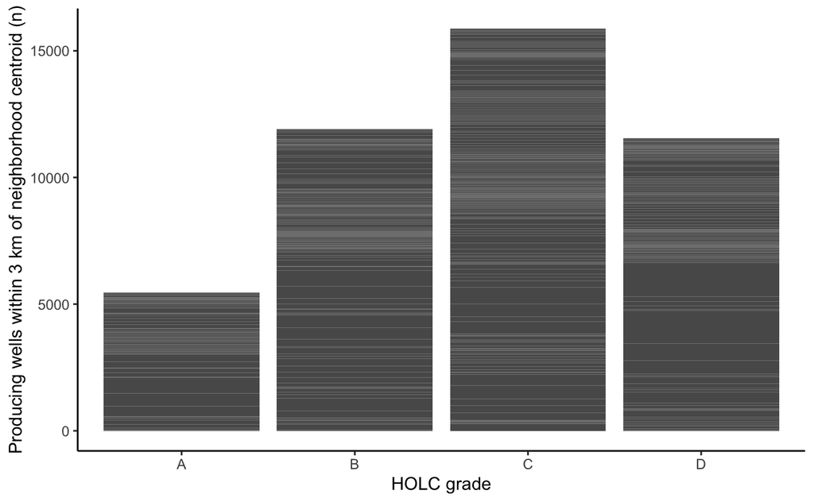

#### Plot. Histogram of n producing wells within 3 km, by city

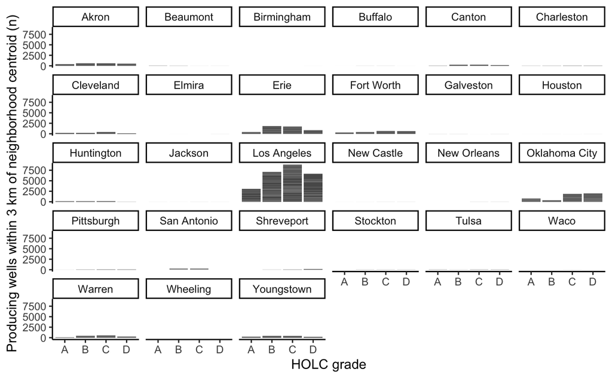